# DTI traveling subjects reproducibility analysis

Brian B. Avants

2024-02-21

# ROI and tabSIMLR reproducibility in T1w and DTI

## overview

- we use data from a traveling subject DTI cohort [(here)](https://doi.org/10.1016/j.mri.2019.02.011)
  - a traveling cohort : 3 healthy subjects travel to 4 sites to be imaged
  - sites represent variability in both MRI manufacturer and MRI model (high variability)
- this enables us to investigate the reliability of our imaging-derived phenotypes (IDPs)
  - IDPs computed with ANTsPyMM (latest version)
  - we use the intraclass correlation coefficient (ICC) to assess consistency or reproducibility of the quantitative IDPs
- the majority of IDPs show superior reliability
  - joint reduction of IDPs with SiMLR improves reliability further

**ANTsPyMM IDPs derived from the same subjects imaged at different sites with MRI from various manufacturers show overall high reliability.** This provides empirical evidence that multiple modality MRI may be used to derive quantitative phenotypes on which predictive models may be based.

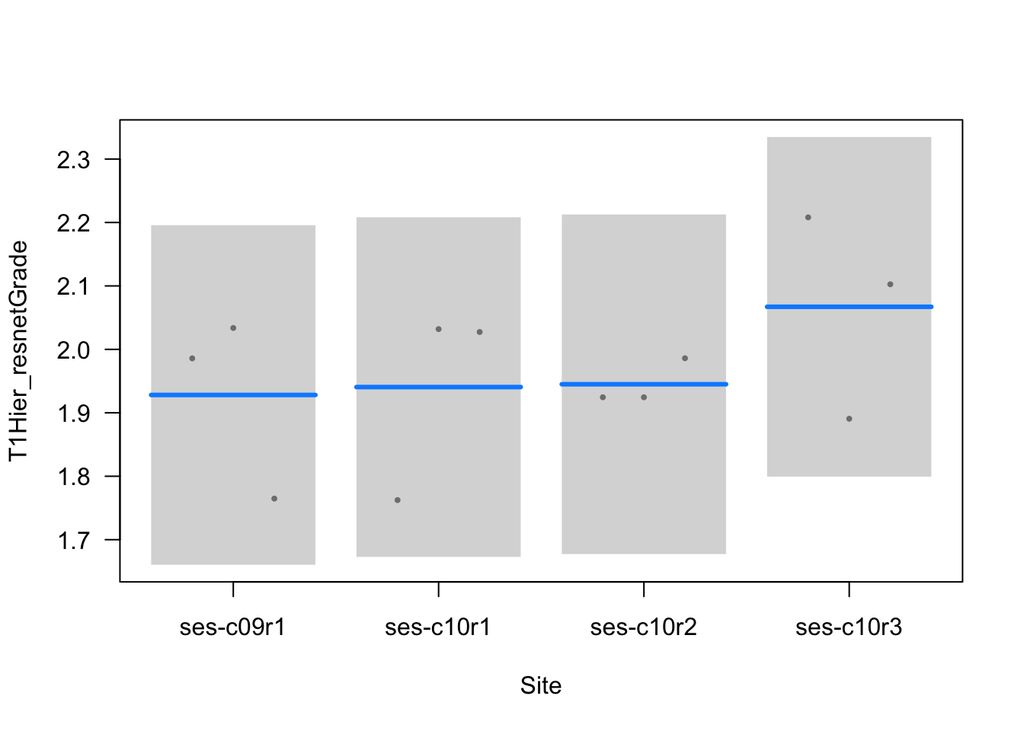

Demonstrate effect of subject vs effect of Scanner or Site

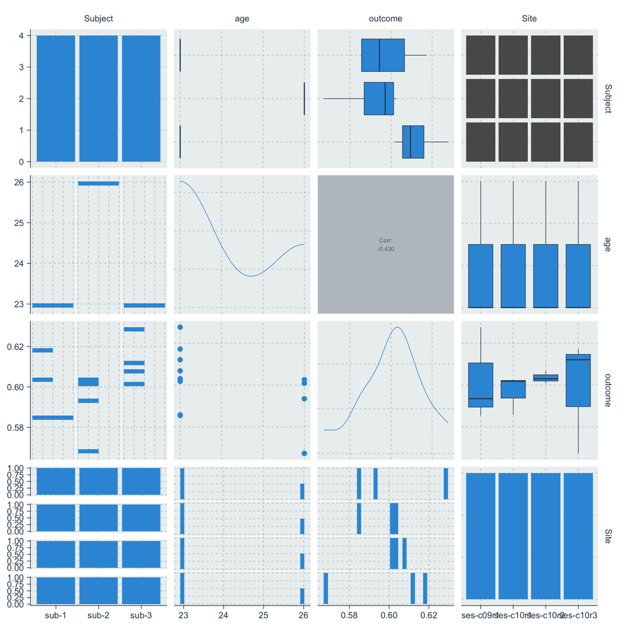

What is the variability of the measurement if we control for age alone?

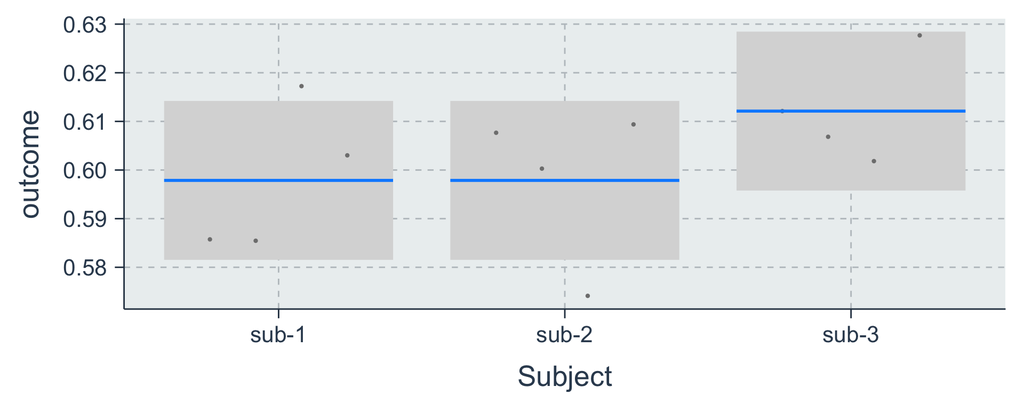

```r
mdl=(lm( outcome ~  age + Subject , data=dd ))
visreg::visreg( mdl, "Subject", gg=TRUE )
```

What is the reproducibility of the measurement if we control for noise?

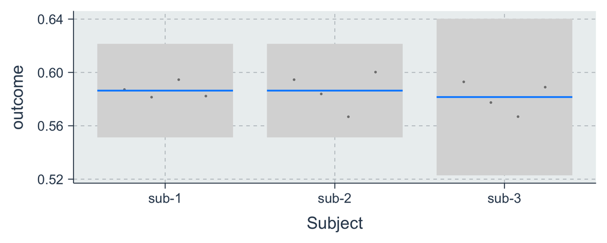

```r
mdl=(lm( outcome ~  age + Subject + Site + DTI_dti_tsnr_b0_mean , data=dd ))
visreg::visreg( mdl, "Subject", gg=TRUE )
```

```r
# grid.arrange( grobs = visreg::visreg( mdl, gg=TRUE ), ncol=1, main='reproducibility' )
```

What is the effect of gray matter resnetGrade?

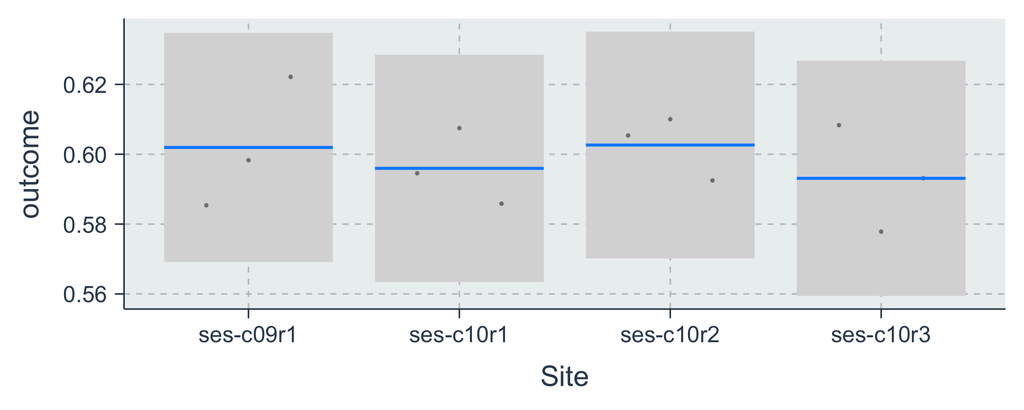

```r
mdl=(lm( outcome ~  age + Subject + Site + T1Hier_resnetGrade , data=dd ))
visreg::visreg( mdl, 'Site', gg=TRUE )
```

What is the effect of age if we control for the best confounds?

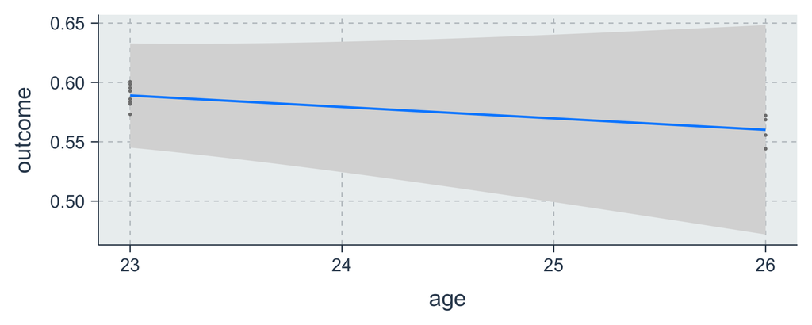

```r
library(lme4)
mdl=(lm( outcome ~  age  + DTI_dti_tsnr_b0_mean+ Site + T1Hier_resnetGrade +(Subject), data=dd ))
# mdl=(lm( outcome ~  age   +(Subject), data=dd ))
visreg::visreg( mdl, 'age', gg=TRUE, main="FIXME" )
```

What is the reproducibility of the measurement if we control for motion?

```r
mdl=(lm( outcome ~ Subject + DTI_dti_tsnr_b0_mean + DTI_dti_FD_mean, data=dd ))
grid.arrange( grobs = visreg::visreg( mdl, 'Subject', gg=TRUE ), ncol=1, main='reproducibility' )
```

[output not shown]

try mixed models to estimate icc

ICC(2,k) (Two-Way Random, Absolute Agreement, Average Measures): This version is used when the raters (or measurement devices) are considered random samples from a larger population of raters and you want to generalize your findings to this broader context. It’s appropriate when different imaging sites might use different equipment or personnel, and you wish to assess the reliability of measurements across these variable conditions.

Summmary reliability data by Site

```
##
## Coefficient of Variation (%):  1.22
## Standard Error of Measurement (SEM):  0.00138
## Standard Error of the Estimate (SEE):  0.00278
## Standard Error of Prediction (SEP):  0.00397
##
## Intraclass Correlation Coefficients with  95 % C.I.
##            Model         Measures  Type    ICC Lower CI Upper CI
## 1 one-way random        Agreement  ICC1 0.9227   0.7232   0.9958
## 2 two-way random        Agreement  ICC2 0.9234   0.6951   0.9958
## 3  two-way fixed      Consistency  ICC3 0.9593   0.8144   0.9978
## 4 one-way random   Avg. Agreement ICC1k 0.9795   0.9127   0.9989
## 5 two-way random   Avg. Agreement ICC2k 0.9797   0.9012   0.9989
## 6  two-way fixed Avg. Consistency ICC3k 0.9895   0.9461   0.9995
##
## [1] "DTI_mean_fa_LRAVG_middle_temporal"
##
## Coefficient of Variation (%):  1.05
## Standard Error of Measurement (SEM):  111
## Standard Error of the Estimate (SEE):  236
## Standard Error of Prediction (SEP):  334
##
## Intraclass Correlation Coefficients with  95 % C.I.
##            Model         Measures  Type    ICC Lower CI Upper CI
## 1 one-way random        Agreement  ICC1 0.8859   0.6203   0.9936
## 2 two-way random        Agreement  ICC2 0.8889   0.4771   0.9935
## 3  two-way fixed      Consistency  ICC3 0.9930   0.9649   0.9996
## 4 one-way random   Avg. Agreement ICC1k 0.9688   0.8673   0.9984
## 5 two-way random   Avg. Agreement ICC2k 0.9697   0.7849   0.9984
## 6  two-way fixed Avg. Consistency ICC3k 0.9982   0.9910   0.9999
##
## [1] "T1Hier_vol_LRAVG_lateral_occipitaldktcortex"
##
## Coefficient of Variation (%):  6.48
## Standard Error of Measurement (SEM):  0.00825
## Standard Error of the Estimate (SEE):  0.0151
## Standard Error of Prediction (SEP):  0.023
##
## Intraclass Correlation Coefficients with  95 % C.I.
##            Model         Measures  Type    ICC Lower CI Upper CI
```

[output cut: 25 more lines]

```
## Coefficient of Variation (%):  1.36
## Standard Error of Measurement (SEM):  0.00144
## Standard Error of the Estimate (SEE):  0.00284
## Standard Error of Prediction (SEP):  0.00408
##
## Intraclass Correlation Coefficients with  95 % C.I.
##            Model         Measures  Type    ICC Lower CI Upper CI
## 1 one-way random        Agreement  ICC1 0.9444   0.7917   0.9970
## 2 two-way random        Agreement  ICC2 0.9445   0.7916   0.9970
## 3  two-way fixed      Consistency  ICC3 0.9498   0.7768   0.9973
## 4 one-way random   Avg. Agreement ICC1k 0.9855   0.9383   0.9993
## 5 two-way random   Avg. Agreement ICC2k 0.9855   0.9383   0.9993
## 6  two-way fixed Avg. Consistency ICC3k 0.9870   0.9330   0.9993
##
## [1] "DTI_mean_fa_LRAVG_supramarginal"
```

Site-wise reliability

```
##                            anat       icc
## 39 fa_caudal_anterior_cingulate 0.6448153
## 87                      fa_exa_ 0.7361783
## 71           fa_deep_bn_gp_gpi_ 0.9663946
## 28   vol_supramarginaldktcortex 0.9665285
## 49     fa_lateral_orbitofrontal 0.9700594
## 19   vol_pericalcarinedktcortex 0.9858116
## 32    vol_bn_str_ca_deep_cit168 0.9945898
```

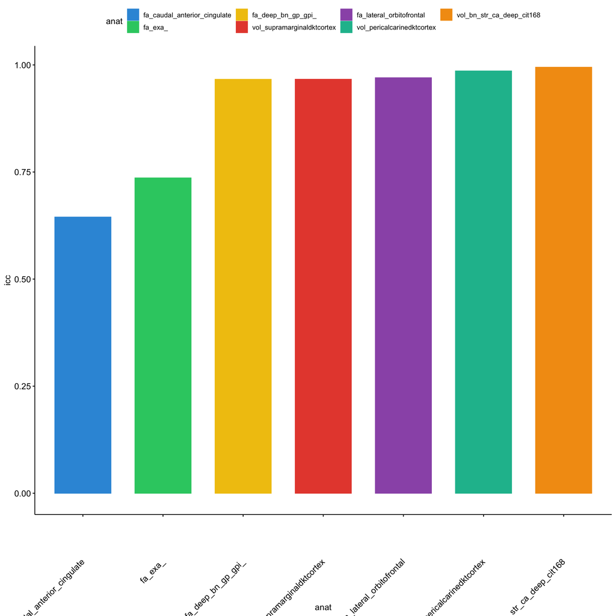

# how many fall in each category

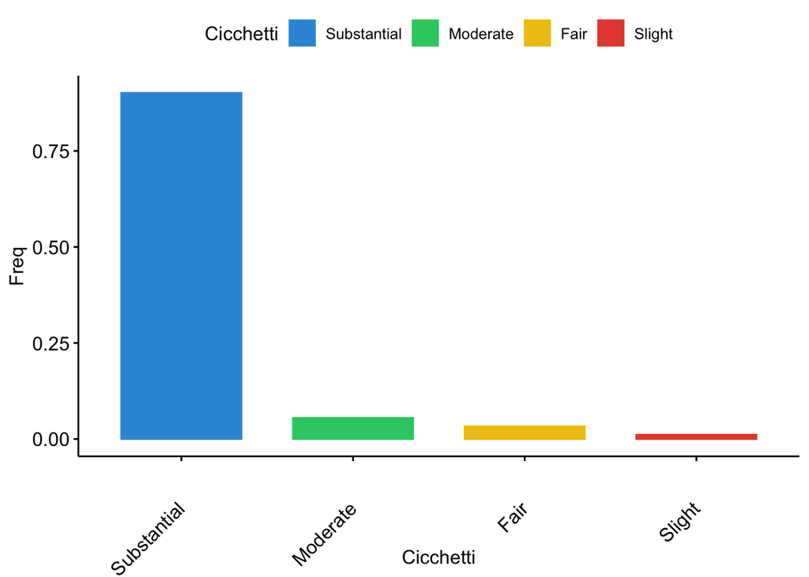

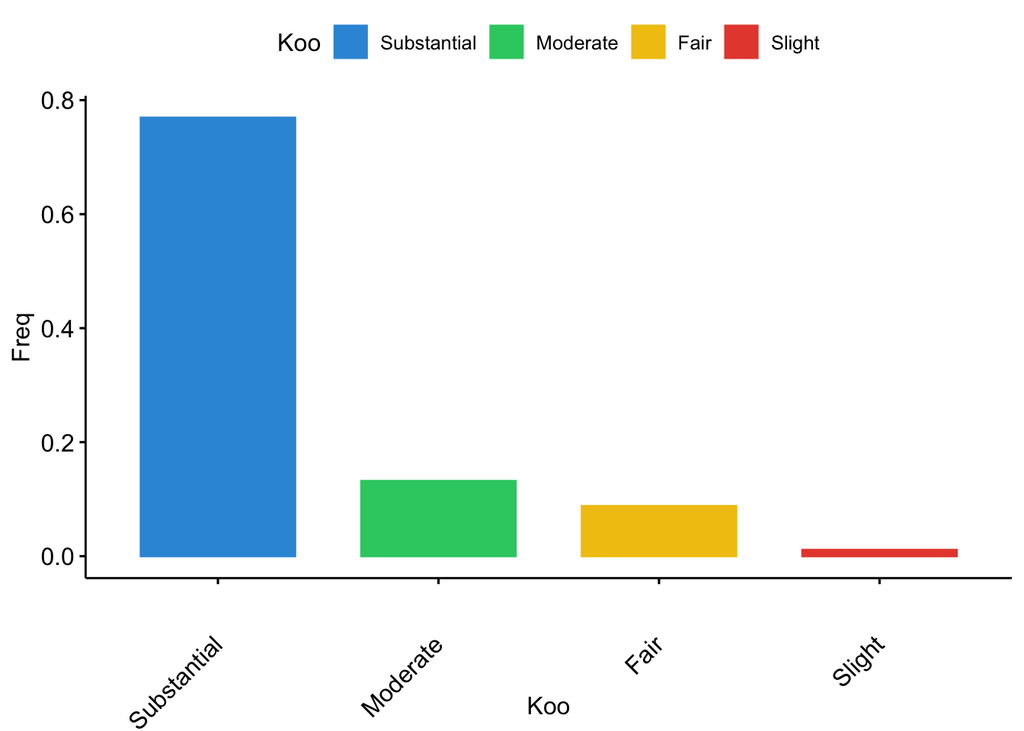

# this is “the same” as the SRPBS analysis

Site-wise reliability

```
##                         anat       icc
## 89            fa_mtg_sn_snc_ 0.2901942
## 64 fa_rostral_middle_frontal 0.6950816
## 70        fa_deep_bn_gp_gpe_ 0.8338375
## 46                 fa_insula 0.9418879
## 32 vol_bn_str_ca_deep_cit168 0.9946059
```

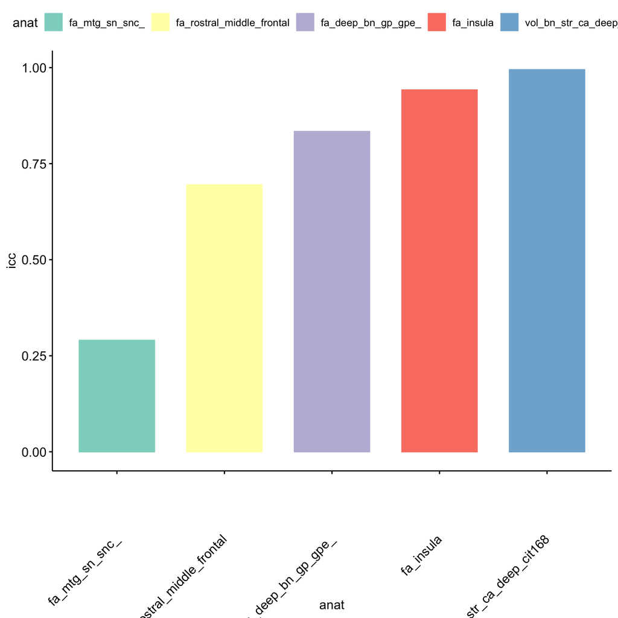

## how does site impact image quality

- higher scores are better
- a few sites are lower quality
- a few subjects exhibit lower quality (consistently)

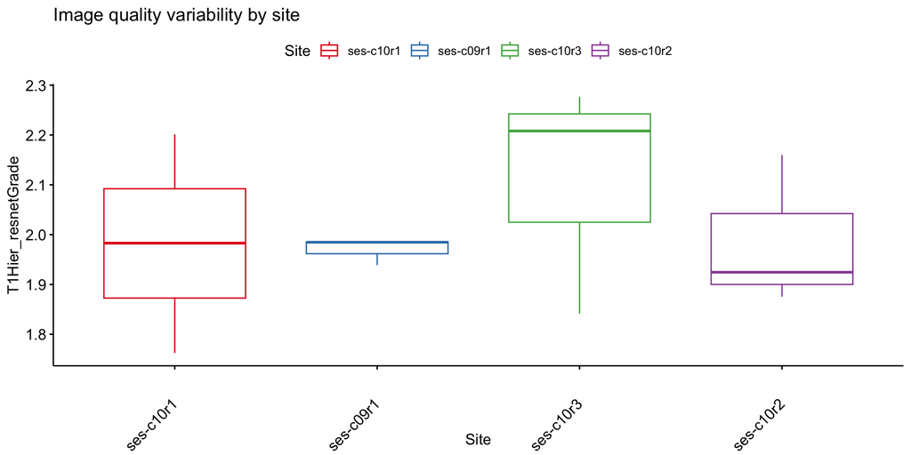

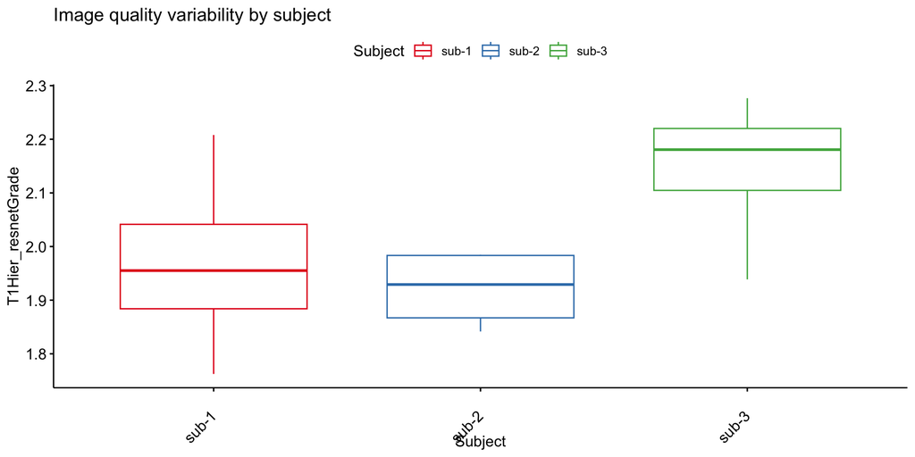

## raw ICC for ROI representation

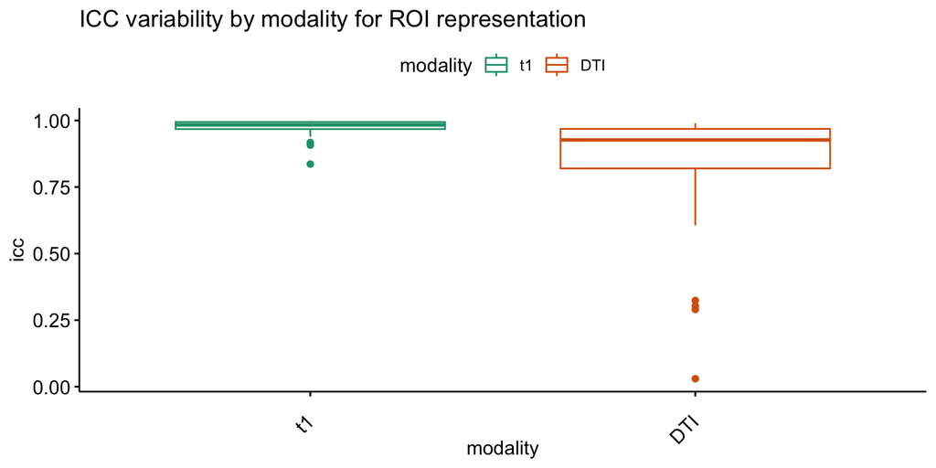

# how many ROIs fall in each category of ICC

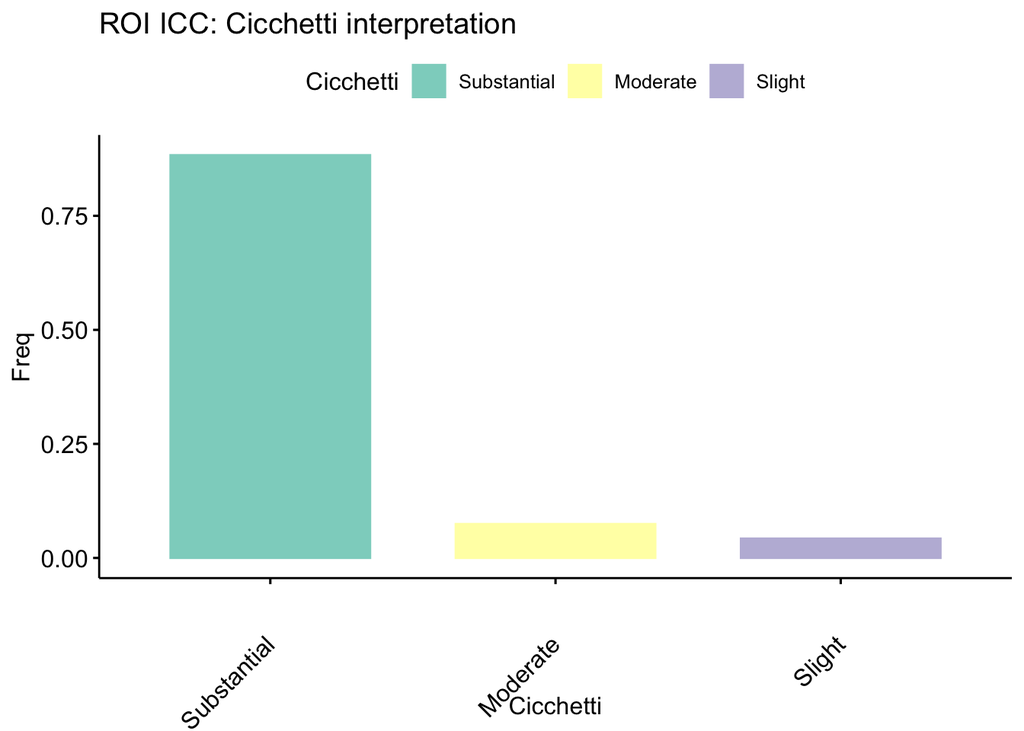

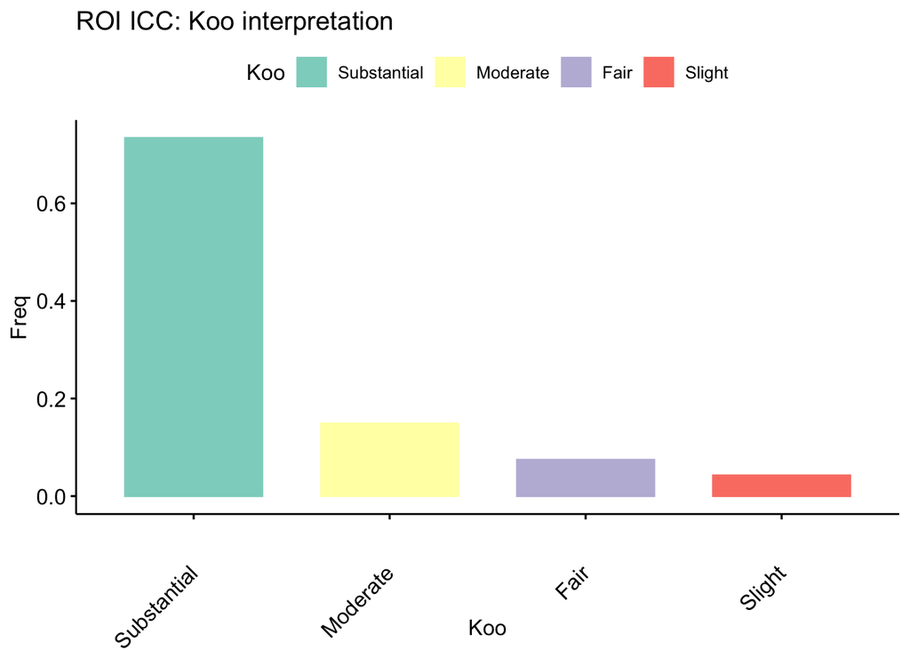

## Do SiMLR-derived IDPs improve reliability? training testing paradigm across sites

- train simlr on each of top quality sites
  - association of T1-derived IDPs and DTI IDPs
  - default parameters for SiMLR (regression and ICA)
- test on each other site
  - just means projecting the IDPs onto the SiMLR bases for both T1 and DTI
- this lets us look at ICC in the simlr space
  - shows that SiMLR latent space (generally) improves ICC over raw ROI representation

```
## [1] "USE SITE:  ses-c10r3"
## [1] "USE SITE:  ses-c10r2"
## [1] "USE SITE:  ses-c10r1"
## [1] "USE SITE:  ses-c09r1"
```

## raw simlr ICC values

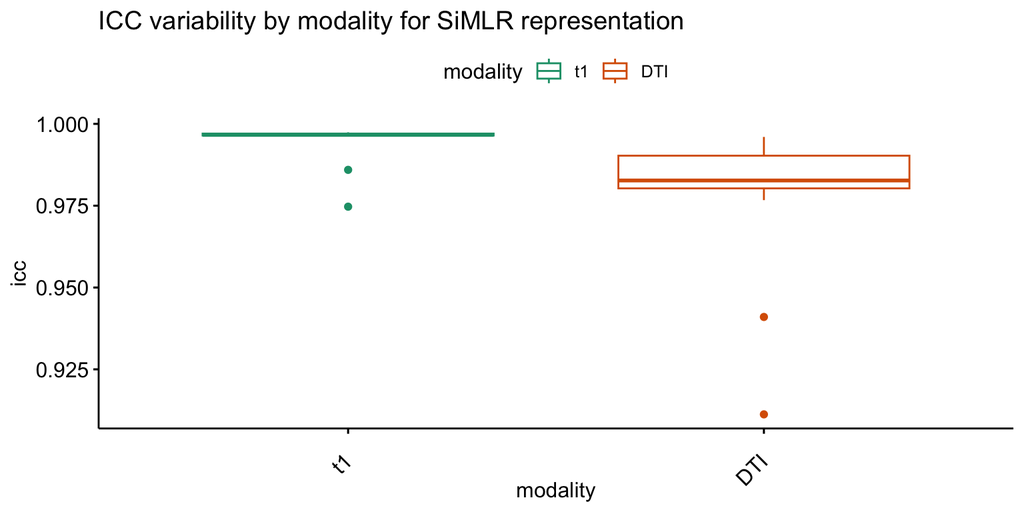

## simlr ICC interpretation

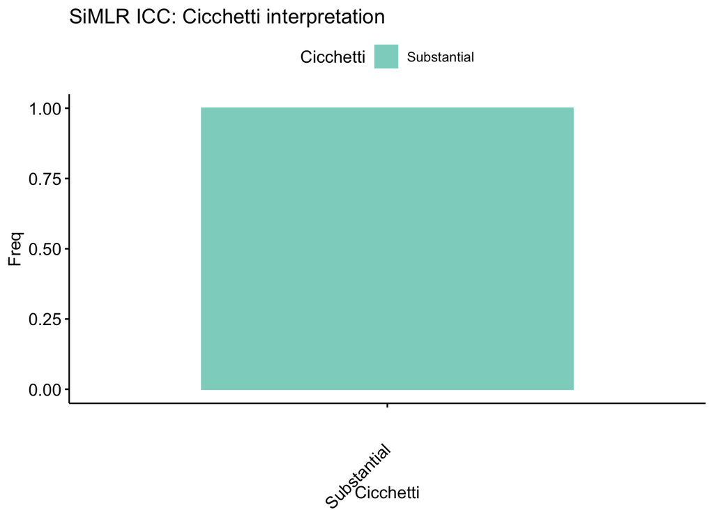

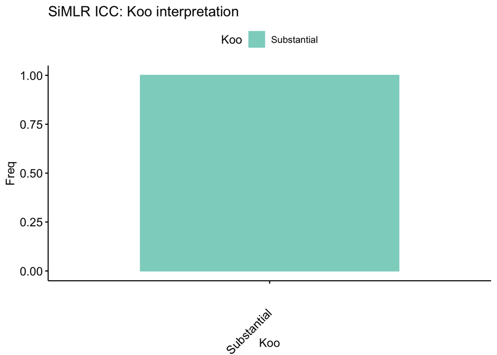

## simple t-test between two representations

```
## [1] "T-test of SiMLR vs ROI representation: T1 IDPs"
```

```
##
##  Welch Two Sample t-test
##
## data:  myiccsimlr[t1sel2, "icc"] and myiccs[t1sel1, "icc"]
## t = 3.7307, df = 43.977, p-value = 0.0005439
## alternative hypothesis: true difference in means is not equal to 0
## 95 percent confidence interval:
##  0.00969828 0.03248791
## sample estimates:
## mean of x mean of y
## 0.9940904 0.9729973
```

```
## [1] "T-test of SiMLR vs ROI representation: DTI IDPs"
```

```
##
##  Welch Two Sample t-test
##
## data:  myiccsimlr[rssel2, "icc"] and myiccs[rssel1, "icc"]
## t = 4.775, df = 62.753, p-value = 1.118e-05
## alternative hypothesis: true difference in means is not equal to 0
## 95 percent confidence interval:
##  0.0765670 0.1867925
## sample estimates:
## mean of x mean of y
## 0.9761770 0.8444972
```

## Summary tabSimlr vs ROIs: ICC IDP reliability in T1w

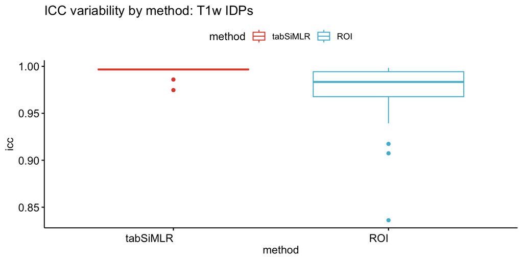

## Summary tabSimlr vs ROIs: ICC IDP reliability in DTI

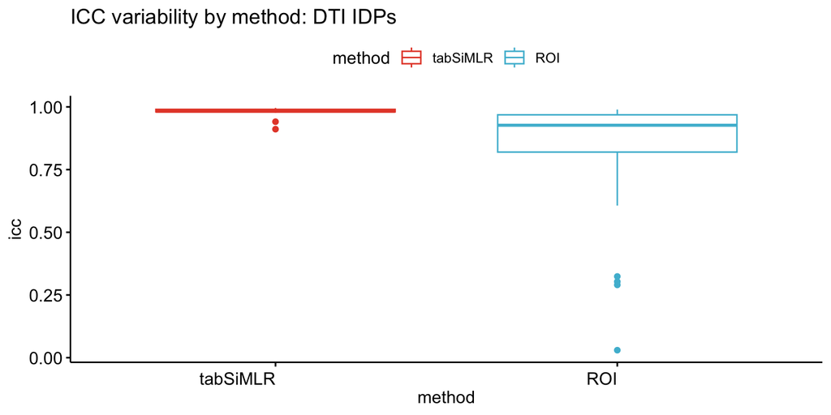